# blog Post 3

GWXYZ

2022-10-28

## Data choice

We decide to use our data set 2, which is College completion data from 3,800 degree-granting institutions in the US. https://data.world/databeats/college-completion

## Data cleaning

we first cleaned the data by removing variables that has too many missing value and has no contribution to our data analysis. then we replace every missing value which has the letter “NULL” to blank value na, which helps us to better process the data.

```r
library(readr)
library(tidyverse)
cc <- read.csv("/Users/ziv/Documents/ma 415 project/ma4615-fa22-final-project-gwxyz/dataset/cc_institution_details.csv")
cc_clean<- select(cc, -(basic:site), -(vsa_year:cohort_size), -(med_sat_value:med_sat_percentile))%>%
  mutate(across(everything(), ~replace(., . ==  "NULL" , NA)))
```

## Data exploration

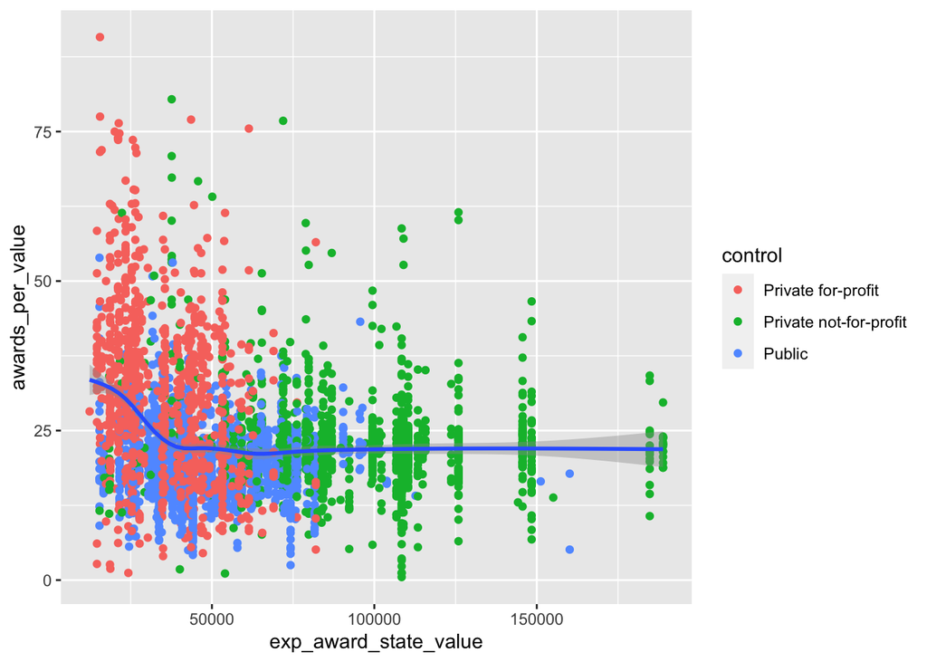

```r
c1<- filter(cc_clean, awards_per_value <100)
ggplot(c1) +
  geom_point(mapping = aes(x = exp_award_state_value, y=awards_per_value, color = control))+
  geom_smooth(mapping = aes(x = exp_award_state_value, y=awards_per_value))
```

```r
summary(cc_clean$exp_award_state_value)
```

```
##    Min. 1st Qu.  Median    Mean 3rd Qu.    Max.
##   12346   35830   54025   61282   79310  188870
```

```r
c1%>% group_by(control)%>%
  summarize(mean_spending = mean(exp_award_state_value, na.rm = TRUE),
            count = n())
```

```
## # A tibble: 3 × 3
##   control                mean_spending count
##   <chr>                          <dbl> <int>
## 1 Private for-profit            36624.   990
## 2 Private not-for-profit        94276.  1247
## 3 Public                        50575.  1558
```

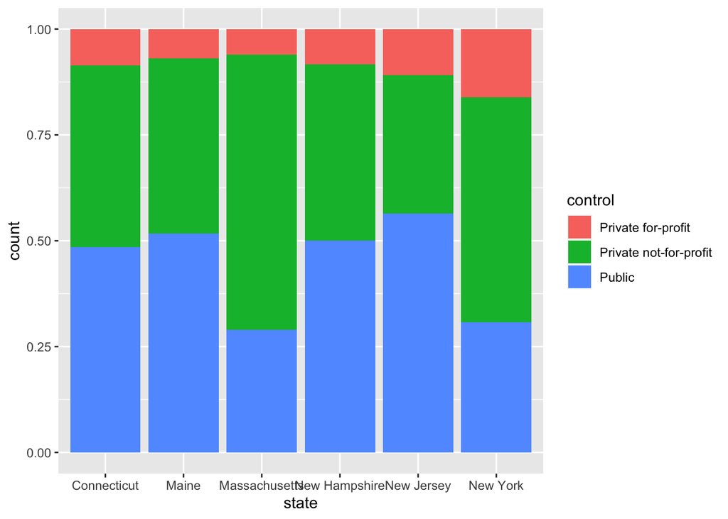

```r
new_england <- filter(cc_clean, state %in% c("Massachusetts","Connecticut", "Maine", "New Hampshire", "New Jersey","New York" ))
ggplot(new_england) + geom_bar(aes(x = state, fill = control), position = "fill")
```

[figure not shown]

```r
ggplot(cc_clean) + geom_bar(aes(x = state, fill = control), position = "fill")
```

```r
new_england%>%
  group_by(state) %>%
  summarize(mean_student = mean(student_count, na.rm = TRUE),
            count = n())
```

```
## # A tibble: 6 × 3
##   state         mean_student count
##   <chr>                <dbl> <int>
## 1 Connecticut          4566.    35
## 2 Maine                2137.    29
## 3 Massachusetts        3741.   100
## 4 New Hampshire        3026.    24
## 5 New Jersey           6313.    55
## 6 New York             4235.   241
```

```r
new_england%>%
  group_by(state) %>%
  summarize(mean_completion = mean(awards_per_value),
            count = n())
```

```
## # A tibble: 6 × 3
##   state         mean_completion count
##   <chr>                   <dbl> <int>
## 1 Connecticut              19.7    35
## 2 Maine                    23.6    29
## 3 Massachusetts            23.2   100
## 4 New Hampshire            23.7    24
## 5 New Jersey               19.9    55
## 6 New York                 23.5   241
```

```
## No summary function supplied, defaulting to `mean_se()`
```

[figure not shown]

```r
country <- cc_clean%>%
  group_by(state) %>%
  summarize(mean_completion = mean(awards_per_value),
            count = n())
ggplot(country) + stat_summary(
  aes(x = state, y = mean_completion), geom = "bar", fill = "orange")
```

```r
summary(cc_clean$awards_per_value)
```

```
##    Min. 1st Qu.  Median    Mean 3rd Qu.    Max.
##    0.50   17.30   21.30   23.44   26.50  137.60
```

We explored school’s completion rate from US and the school in the New England area, which is consistently pretty low with mean value of 23.44% completion